# Tornadoes in Texas 2011-2015

Tornadoes are very destructive weather events that can cause deaths and much property damage. Their severity are measured on the enhanced Fujita scale:

| F Scale | Speed |
| --- | --- |
| EF0 | 65-85 mph (light damage) |
| EF1 | 86-110 mph (moderate damage) |
| EF2 | 111-135 mph (considerable damage) |
| EF3 | 136-165 mph (severe damage) |
| EF4 | 166-200 mph (devastating damage) |
| EF5 | > 200 mph (incredible damage) |

In which months do tornadoes tend to occur? What time? Is there a pattern to where the strongest tornadoes occur?

We will investigate tornadoes in the state of Texas from January 1, 2011 through December 31, 2015. The data, in the file **tornadoes11-15.txt**, were obtained from the Storm Events Database at the National Centers for Environmental Information www.ncdc.noaa.gov

We will need the packages `stringr`, `lubridate`, `ggplot2`, `dplyr` and `plyr` for this lab:

```r
for (package in c("stringr", "lubridate", "ggplot2", "plyr", "dplyr")){
  library(package, character.only = TRUE)
}
```

The values in the variable `BeginTime` (the time the tornado began) in the text file are quoted because some of the times have leading zeros (for example, “0305” for 3:05 am). However, even with the double quotes, R infers that this column is numeric and strips off the leading zeros. We will use the `colClasses` argument to `read.table` to force R to read this variable as a character variable.

```r
tornadoes <- read.table("data/TxTornadoes11-15.txt",
        colClasses=c(Fscale = "factor", Source = "factor",
        BeginTime="character"), stringsAsFactors = FALSE,
        header = TRUE, sep = ",")

dim(tornadoes)
```

```
## [1] 620  20
```

There were 620 tornadoes recorded in this time frame.

### Extracting the time information

The date (`BeginDate`) and time (`BeginTime`) of the tornadoes are given as separate variables so we will combine them into one variable. In addition, the time variable will also need to be converted into the hh:mm:ss format.

The `BeginTime` variable has the hour and minute information of when the tornado began, but without the “:” separator. We will use the `str_sub` command from the `stringr` package to extract the hours and minutes portion from this variable and then use the base R command `paste` to glue them back together with the “:” separator.

```r
head(tornadoes$BeginTime)
```

```
## [1] "0325" "0329" "0610" "1610" "1715" "1803"
```

```r
temp1 <- str_sub(tornadoes$BeginTime, 1, 2)
head(temp1)
```

```
## [1] "03" "03" "06" "16" "17" "18"
```

```r
temp2 <- str_sub(tornadoes$BeginTime, 3, 4)
head(temp2)
```

```
## [1] "25" "29" "10" "10" "15" "03"
```

```r
temp3 <- paste(temp1, ":", temp2, ":", "00", sep = "")
head(temp3)
```

```
## [1] "03:25:00" "03:29:00" "06:10:00" "16:10:00" "17:15:00" "18:03:00"
```

```r
temp4 <- paste(tornadoes$BeginDate, temp3, sep = " ")
head(temp4)
```

```
## [1] "1/9/2011 03:25:00"  "1/9/2011 03:29:00"  "2/1/2011 06:10:00"
## [4] "3/8/2011 16:10:00"  "3/8/2011 17:15:00"  "3/19/2011 18:03:00"
```

```r
temp5 <- mdy_hms(temp4)
head(temp5)
```

```
## [1] "2011-01-09 03:25:00 UTC" "2011-01-09 03:29:00 UTC"
## [3] "2011-02-01 06:10:00 UTC" "2011-03-08 16:10:00 UTC"
## [5] "2011-03-08 17:15:00 UTC" "2011-03-19 18:03:00 UTC"
```

```r
tornadoes$DateTime <- temp5
```

**Remark** All the times in the data set were given in Central Standard Time (CST). For the purposes of this lab, ignore the default UTC designation in the output.

### When do tornadoes occur?

When do most tornadoes occur? Do they tend to occur in the same months from year to year? To answer this, we can use base R and `ggplot2` commands which can handling date objects.

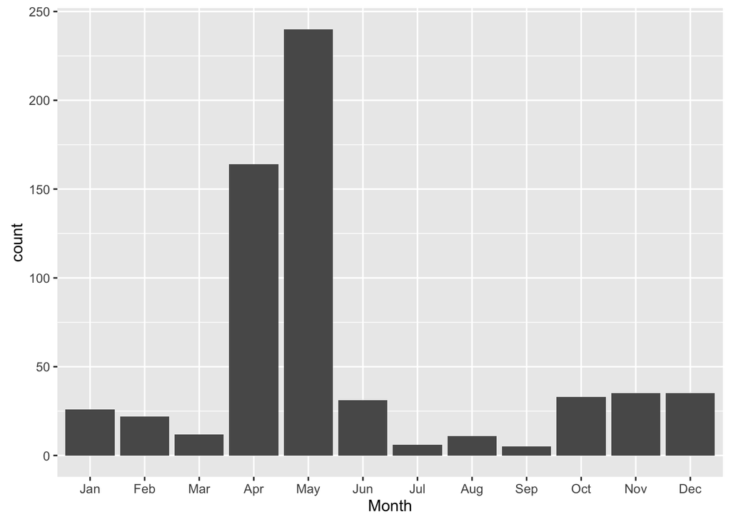

```r
tornadoes$Month <- month(tornadoes$DateTime, label = TRUE)
ggplot(tornadoes, aes(Month)) + geom_bar()
```

```r
table(tornadoes$Month)
```

```
##
## Jan Feb Mar Apr May Jun Jul Aug Sep Oct Nov Dec
##  26  22  12 164 240  31   6  11   5  33  35  35
```

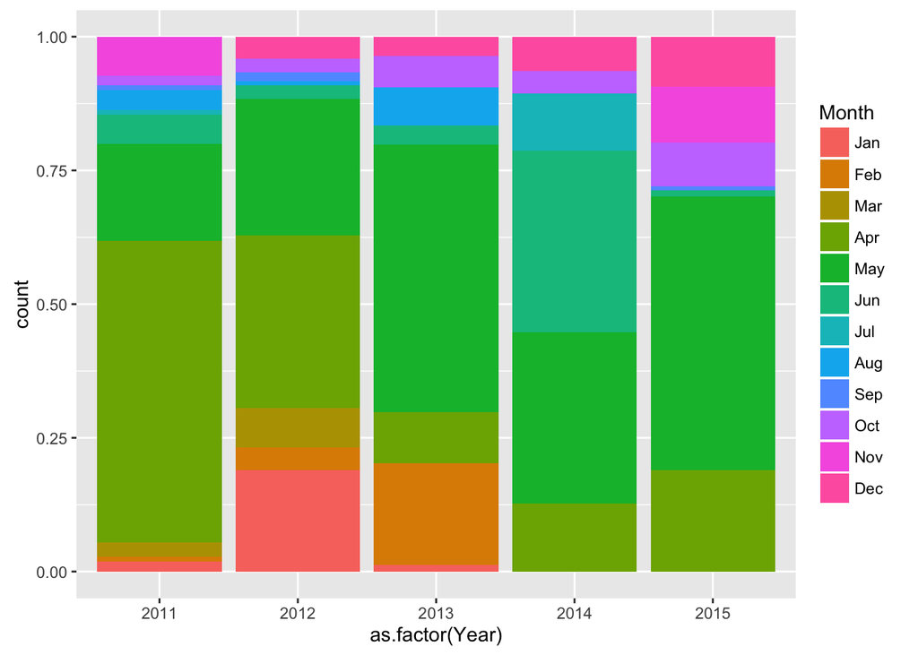

```r
tornadoes$Year <- year(tornadoes$DateTime)
ggplot(tornadoes, aes(x=as.factor(Year))) + geom_bar(aes(fill =Month), position = "fill")
```

Thus, we see that of the 620 tornadoes that occurred over this 5 year period, 240 tornados occurred in May and only 5 occurred in September. From the graph, we see that the proportion of a year’s tornados that occur in a given month is not consistent year to year. For example, in this data set, 2015 had a higher fraction of December tornadoes than in other years.

**Remark** To compute proportions instead of counts, use the `prop.table` command. For example

```r
prop.table(table(tornadoes$Year, tornadoes$Month), 1)
```

```
##
##                Jan         Feb         Mar         Apr         May
##   2011 0.018181818 0.009090909 0.027272727 0.563636364 0.181818182
##   2012 0.190082645 0.041322314 0.074380165 0.322314050 0.256198347
##   2013 0.011904762 0.190476190 0.000000000 0.095238095 0.500000000
##   2014 0.000000000 0.000000000 0.000000000 0.127659574 0.319148936
##   2015 0.000000000 0.000000000 0.000000000 0.189922481 0.511627907
##
##                Jun         Jul         Aug         Sep         Oct
##   2011 0.054545455 0.009090909 0.036363636 0.009090909 0.018181818
##   2012 0.024793388 0.000000000 0.008264463 0.016528926 0.024793388
##   2013 0.035714286 0.000000000 0.071428571 0.000000000 0.059523810
##   2014 0.340425532 0.106382979 0.000000000 0.000000000 0.042553191
##   2015 0.011627907 0.000000000 0.000000000 0.007751938 0.081395349
##
##                Nov         Dec
##   2011 0.072727273 0.000000000
##   2012 0.000000000 0.041322314
##   2013 0.000000000 0.035714286
##   2014 0.000000000 0.063829787
##   2015 0.104651163 0.093023256
```

What time did these tornadoes occur? Do they tend to occur in certain periods of the day?

```r
TorTime <- hour(tornadoes$DateTime)
head(TorTime)
```

```
## [1]  3  3  6 16 17 18
```

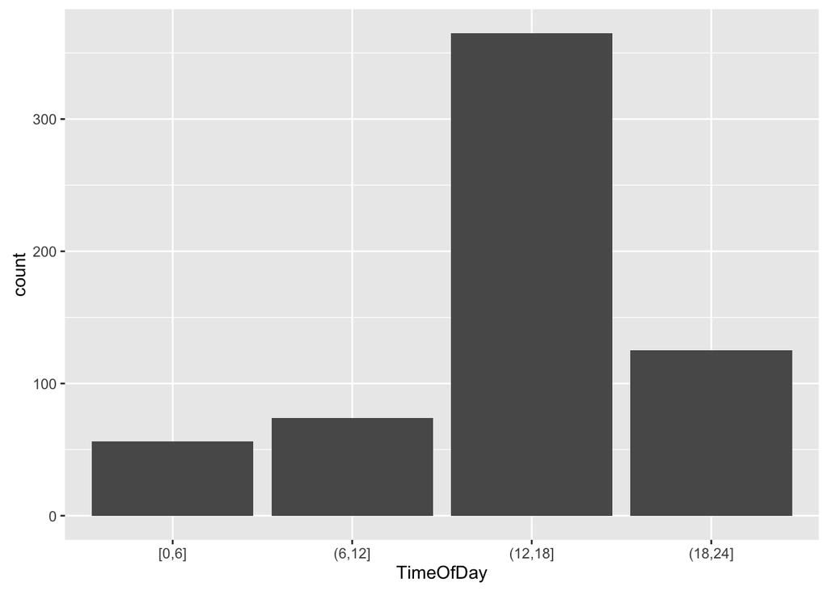

```r
tornadoes$TimeOfDay <- cut(TorTime, breaks=c(0,6,12,18, 24), include.lowest = TRUE)

ggplot(tornadoes, aes(TimeOfDay)) + geom_bar()
```

```r
prop.table(table(tornadoes$TimeOfDay))
```

```
##
##      [0,6]     (6,12]    (12,18]    (18,24]
## 0.09032258 0.11935484 0.58870968 0.20161290
```

**Remark** The `cut` command creates a factor variable from a numeric variable by placing each value into an interval determined the `breaks` argument.

### How strong were the tornadoes?

How strong were the tornadoes that hit Texas? Is there any relationship between strength of tornado and time of occurrence?

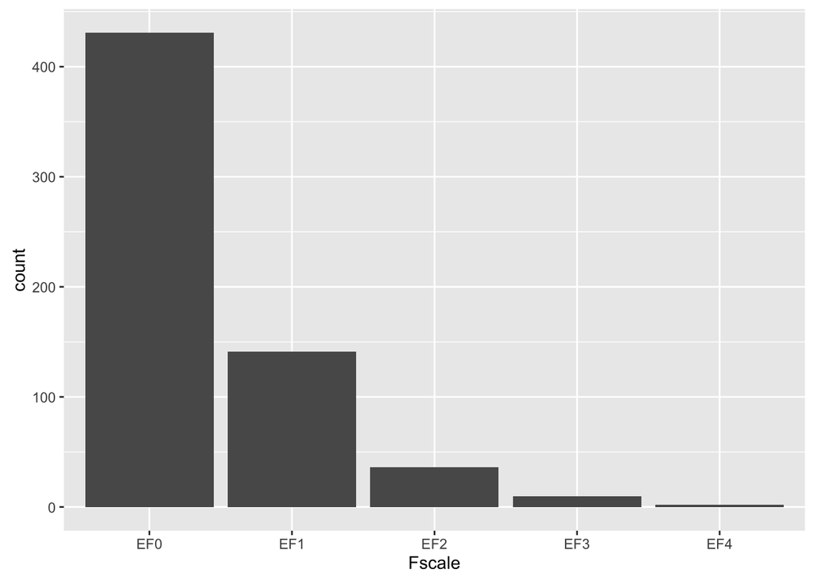

```r
ggplot(tornadoes, aes(x = Fscale)) + geom_bar()
```

```r
prop.table(table(tornadoes$Fscale, tornadoes$TimeOfDay), 1)
```

```
##
##            [0,6]     (6,12]    (12,18]    (18,24]
##   EF0 0.05336427 0.12993039 0.63805104 0.17865429
##   EF1 0.19148936 0.09929078 0.43262411 0.27659574
##   EF2 0.16666667 0.08333333 0.61111111 0.13888889
##   EF3 0.00000000 0.10000000 0.50000000 0.40000000
##   EF4 0.00000000 0.00000000 1.00000000 0.00000000
```

We see that most tornadoes in Texas were EF0. About 43.3% of EF1 tornadoes occurred between noon and 6pm, while 27.6% of them occurred between 6pm and midnight.

Other common operations work on dates also. For instance, suppose we want to know what fraction of the tornadoes in this data set occurred after June 30, 2014.

```r
AfterJune30 <- tornadoes$DateTime > mdy_hms("06-30-2014 23:59:59")
head(AfterJune30)
```

```
## [1] FALSE FALSE FALSE FALSE FALSE FALSE
```

```r
mean(AfterJune30)
```

```
## [1] 0.4322581
```

About 43.2% of tornadoes in this data set occurred after June 30, 2014.

### Mapping the tornadoes

We can visualize the occurrences of tornadoes on a map. First, some preparation.

The enhanced Fujita scale variable, `Fscale` is a factor variable but we need a numeric version for one of the `ggplot2` commands. We will use the `plyr` package to map the levels of this variable to the numeric values 0, 1, 2, 3, 4.

```r
tornadoes$F2 <- as.numeric(mapvalues(tornadoes$Fscale, from = levels(tornadoes$Fscale), to = 0:4))
```

Now, we will use the command `map_data` from `ggplot2` to get the outline for the state of Texas. We will store this portion of the plot in the R object `p`.

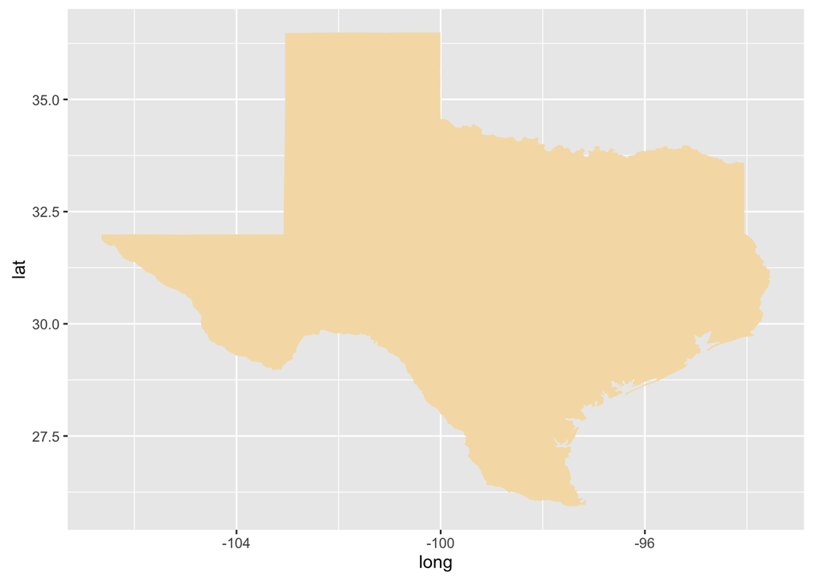

```r
Txmap <- map_data("state", region="Texas")

p <- ggplot(tornadoes) +
     geom_polygon(data = Txmap, aes(x=long, y = lat),
       fill="wheat")

p
```

Now, we will plot the latitude and longitude of where each tornado began. Since we want to add a layer to the Texas map, we will reuse the gg object `p` created above.

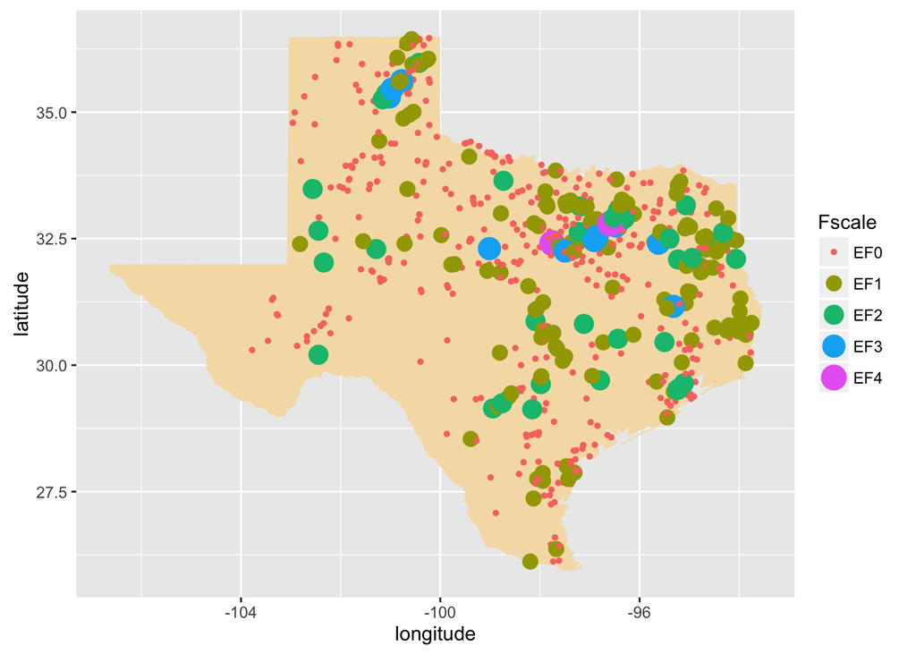

```r
p + geom_point(aes(x = BeginLon, y = BeginLat, size = F2,   color=Fscale)) +
  labs(x = "longitude", y = "latitude", size = "Fscale") +  scale_size_continuous(labels=c("EF0", "EF1", "EF2", "EF3", "EF4"))
```

Is there is any spatial pattern to when the tornadoes occurred?

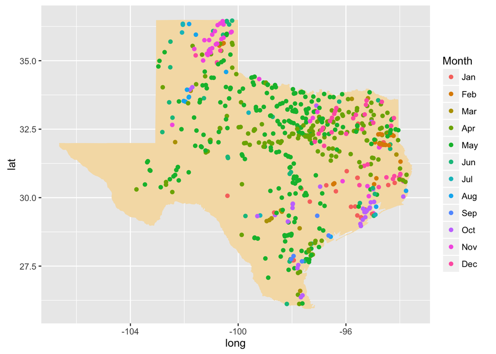

```r
p + geom_point(aes(x = BeginLon, y = BeginLat, color=Month))
```

We saw earlier that most tornadoes were either EF0 or EF1 on the enhanced Fujita scale. Let’s map where the more severe tornadoes occurred.

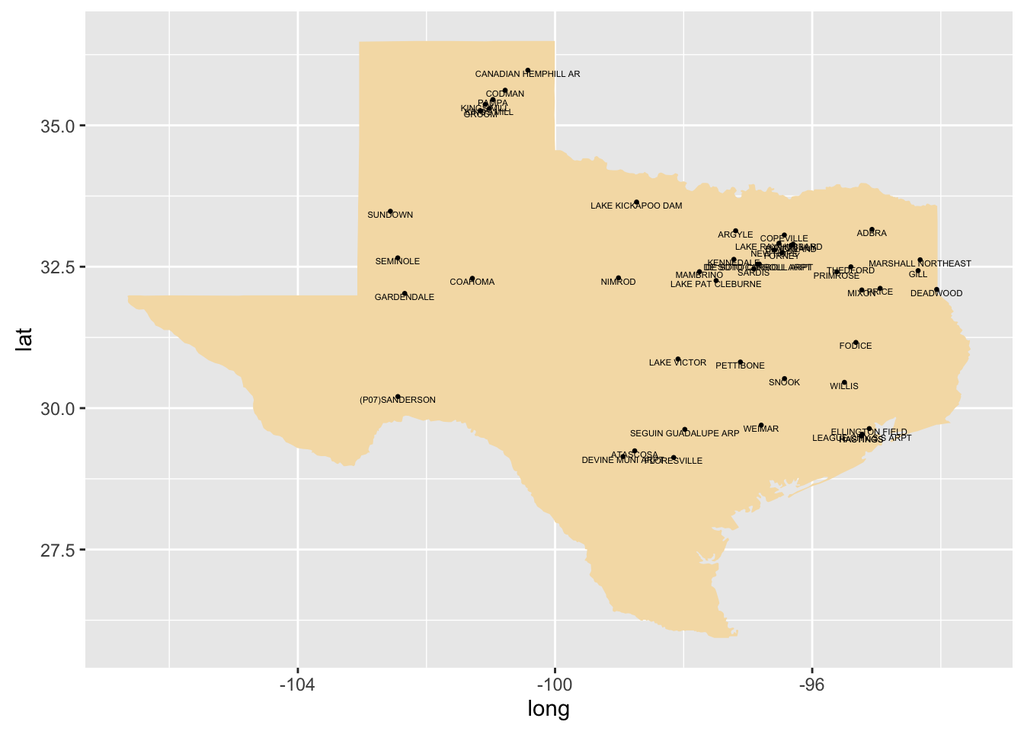

```r
severeTorn <- filter(tornadoes, Fscale=="EF2" | Fscale=="EF3"| Fscale=="EF4")

p <- ggplot(severeTorn) +
    geom_polygon(data = Txmap, aes(x=long, y = lat), fill="wheat")    #recreate Texas map

p + geom_point(aes(x=BeginLon, y = BeginLat), size = .5) +
  geom_text(aes(x=BeginLon, y = BeginLat, label = BeginLocation), size = 1.5, vjust = 1)
```

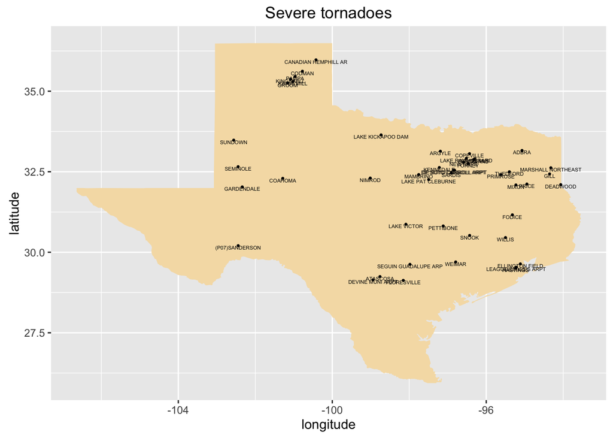

```r
last_plot() +
 labs(x="longitude", y = "latitude") +
 ggtitle("Severe tornadoes")
```

**Remark** The `vjust` argument to `geom_text` shifts the label up or down from the point.

### On Your Own

1. Create a plot to explore the distribution of the log of property damage (`PropertyDamage`) by the F scale. Note that there are many zeros, so add 1 to the property damage variable before taking the log.
2. Is there any geographic pattern to who (storm chasers, the public, etc.) reports the tornado (variable `Source`)?
3. The file **FlLightning10-15.txt** contains data on lightning strikes in Florida between 2010 and 2015. A lightning strike was recorded if there was any property or crop damage, or injuries or deaths (either direct or indirect). This file is comma delimited and the variable `Time` should be imported as character and `Source` as factor.
- In which months did most of the lightning strike occur? Time of day?
- What proportion of lightning strikes in this data set occurred before March 14, 2013?
- Is there any spatial pattern to where the lightning strikes occurred?
4. The default color palettes used by `ggplot2` may not be optimal, especially for those who are color-blind. Explore the package `dichromat`. See https://www.r-bloggers.com/choosing-colour-palettes-part-i-introduction/.